# Prosper Loan Data Exploration

## by Dina El-kholy

## Investigation Overview

> In this project, I wanted to investigate the features that could be used to predict the loan status for a borrower. The main features I focused on was LoanOriginalAmount, StatedMonthlyIncome, DebtToIncomeRatio, Term,EmploymentStatus, EmploymentStatusDuration, Occupation, ListingCategory, and TotalProsperLoans.

## Dataset Overview

> This dataset contains information about 113,937 loans represented by 81 features such as the loan amount, the monthly income, the employment status, and the loan status. More information about the dataset features can be found [here](https://docs.google.com/spreadsheets/d/1gDyi_L4UvIrLTEC6Wri5nbaMmkGmLQBk-Yx3z0XDEtI/edit#gid=0).

## Visualizing the Loan Status in the dataset

> - Most loans are current or completed loans. Almost none of the loans are cancelled.
> - It looks like most loans are paid as expected. However, some are defaulted or past due; I want to inspect whether any of the features can explain the delay?

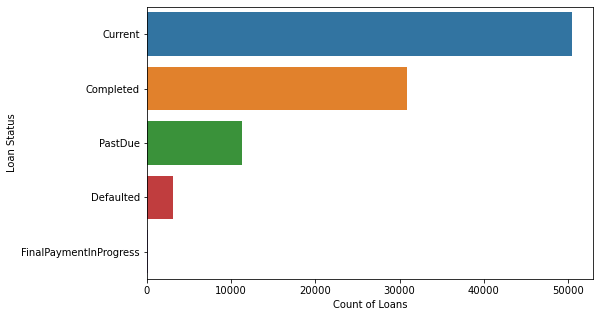

## Visualizing the Monthly Income

> The averge income is skewed towards the right and the avergae income is 5000.

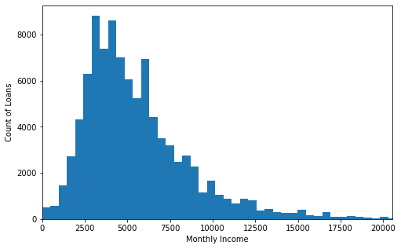

## Visualizing the relation between all numerical features

> From the map, one can see that there is no strong correlation between any of the features. However, the loan amount and the monthly income seem to be correlated. Also, the term of the loan and the loan amount are correlated. There is also a negative correlation between the monthly income and the debt to income ratio which is expected.

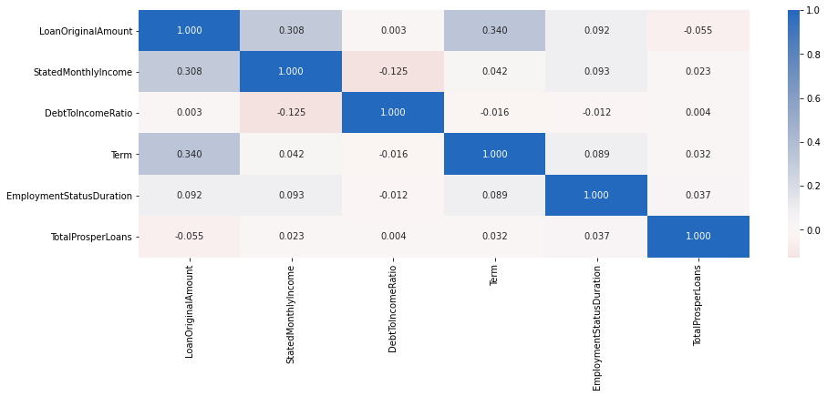

## Visualizing the relation between monthly income, debt to income ratio and loan status

> - From the plots, one can see that there are many outliers in the data especially in the DebtToIncomeRatio feature.
> - Also, we can see that the distribution of the pastDue and the Defaulted loans are nearly the same in regards to the loan amount and the monthly income. I think it will be safe to assume that past due loans will be defaulted eventually. Hence, we can label them all as defaulted loans. I will do that in a future step.
> - Borrowers with Completed or final payment in progress loans seem to have higher income that the borrowers whose loans were defaulted.

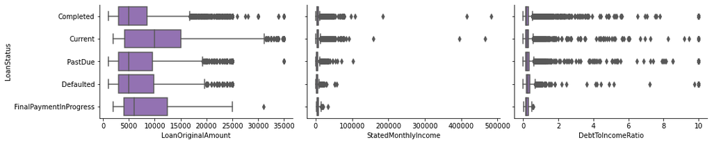

## Visualizing the relation between employment status, loan original amount and loan status

> - Loans with higher loan amount are usually defaulted as expected.
> - Self-employed tend to request the largest loans while not employed borrowers tend to request the lowest loans (expected).
> - Full time borrowers tend to request higher loans than part time borrowers (expected).

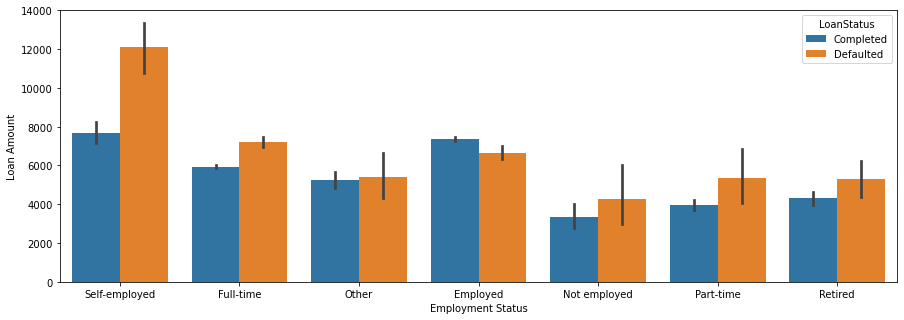